# Ensemble Model to Predict Anemia Diagnosis

DA5030

Gale, Amanda

Fall 2025

## 1 Introduction

My pipeline is designed to create a SQL database within which it saves data obtained from a URL, then rendering a separate R notebook designed to pre-process the data and update the SQL database with the cleaned copy, and finally obtaining the cleaned data set and building predictive models from there. The classification models are designed to predict the diagnosis of patients who are either healthy or suffer from one of eight different types of anemia. Models utilized in this notebook include support vector classifier, random forest, artificial neural network, and a manually constructed heterogeneous ensemble incorporating all three models. These model types were chosen for their compatibility with naturally standardized data such as blood cell counts and their suitability for large multi-class classification problems. Random forest offers interpretability which the other models, as black box algorithms, lack which is a common requirement for healthcare problems.

### 1.1 Create the Project Environment

A virtual environment has been created within this project folder within which all necessary Python libraries have been installed. These imports extend to the entire project environment, meaning that they do not need to be imported again by other files within the pipeline. Here, I am creating a virtual environment within this directory, telling the program to use that virtual environment, and downloading all necessary Python libraries within. Of all the AI assistance and forum browsing done for this project, most of it was for this part.

```r
# tell reticulate not to auto-generate an external venv
Sys.setenv(RETICULATE_AUTOCONFIGURE = "FALSE")

# create virtual environment
virtualenv_create("./.venv")

# require venv
use_virtualenv("./.venv", required = TRUE)

# required Python libraries
required_py_packages <- c("numpy", "pandas", "scikit-learn", "matplotlib", "tabulate", "scipy")

# will check for packages before installing
virtualenv_install("./.venv", required_py_packages)
```

### 1.2 Generate the Data Set

Here, I retrieved the data from a URL and saved it as a Pandas data frame.

```python
url = "https://raw.githubusercontent.com/Xylazine/DataFiles/refs/heads/main/anemia_data.csv"
df = pd.read_csv(url)
df = df.drop(df.columns[0], axis=1)   # delete the indexing column
```

Here, I created a SQL database within the project folder and saved the data as a table to be accessed by other files in the pipeline.

```python
con = sqlite3.connect("anemia_project.db")
df.to_sql('anemia_data', con, if_exists='replace', index=False)
```

```python
con.close()
```

### 1.3 Clean Data

This is where the rendering of the pre-processing notebook in the pipeline takes place, **data_prep.Rmd**. This notebook will create a clean copy of the data set. I found that visualizing the raw data was not very fruitful but that the models performed very well on it, as their performance is dependent on hyperparameter tuning for this particular data set and the data is not particularly messy, per the nature of blood testing being highly standardized. So rather than replace the data set in the database with a highly processed version for demonstrative purposes, I instructed the notebook to create a second copy for visualization while models will be built from the raw data.  
Another approach to this pipeline could have been to simply call functions stored within a *.r* or *.py* file to modify a local copy of the data. However, in the interest of providing a full explanation of data shaping, I have made the data cleaning process into its own .Rmd file that can be viewed separately from this notebook. The pipeline used here would be a good approach for very messy data sets that require thorough pre-processing or when building an ensemble where each model requires distinctly shaped data that can be rendered in their own separate .Rmd files. Here, I use only one pre-processing file for all of my data since my models accept very similarly shaped data.

```r
# render data cleaning notebook
rmarkdown::render("data_prep.Rmd")
```

```python
# retrieve processed data set from database
con = sqlite3.connect('anemia_project.db')
df_clean = pd.read_sql('SELECT * FROM clean_anemia_data', con)
con.close()
```

## 2 Evaluate Data

We can view the distribution of anemia diagnoses. There is a wide class imbalance that might be addressed with SMOTE in another data set. However, this is not an option in this data set as some classes are incredibly rare. Half of the classes are distributed at or below 5% of the data. The data set is already small so it is not feasible to artificially balance this data. However, I will stratify the partitions to ensure that all classes are present at every step of the training and validation process.

```
##
## Diagnosis Class Distribution:
```

```
## Diagnosis
## Healthy                           0.262295
## Normocytic hypochromic anemia     0.217799
## Normocytic normochromic anemia    0.209992
## Iron deficiency anemia            0.147541
## Thrombocytopenia                  0.056987
## Other microcytic anemia           0.046058
## Leukemia                          0.036690
## Macrocytic anemia                 0.014052
## Leukemia with thrombocytopenia    0.008587
## Name: proportion, dtype: float64
```

### 2.1 Visualize Blood Counts by Class

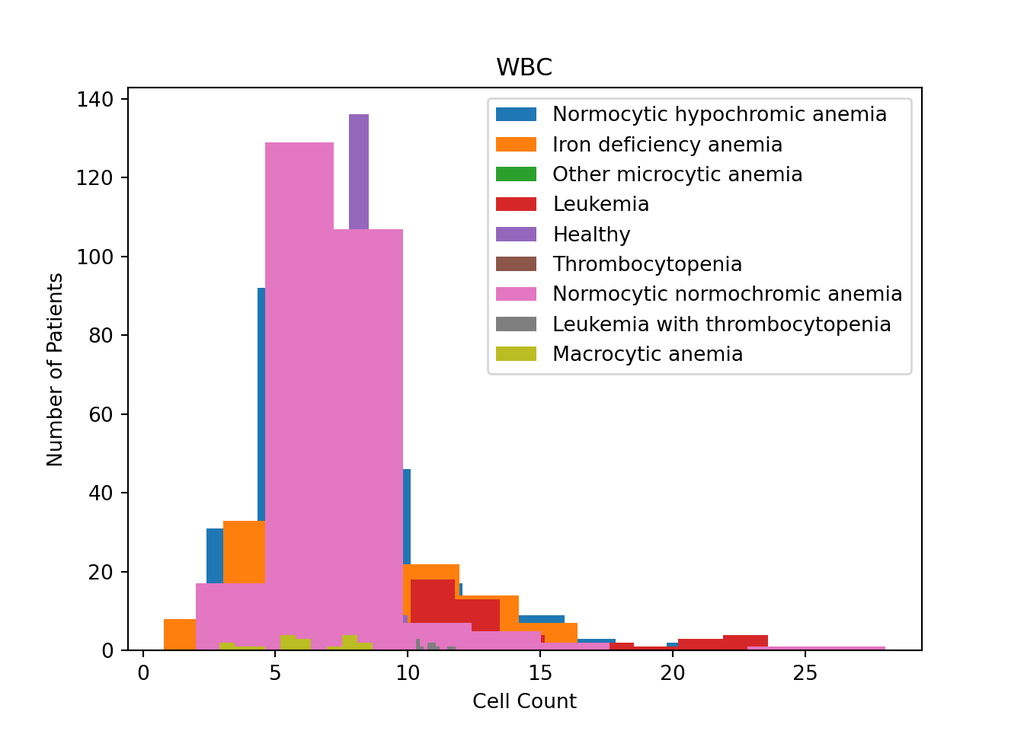

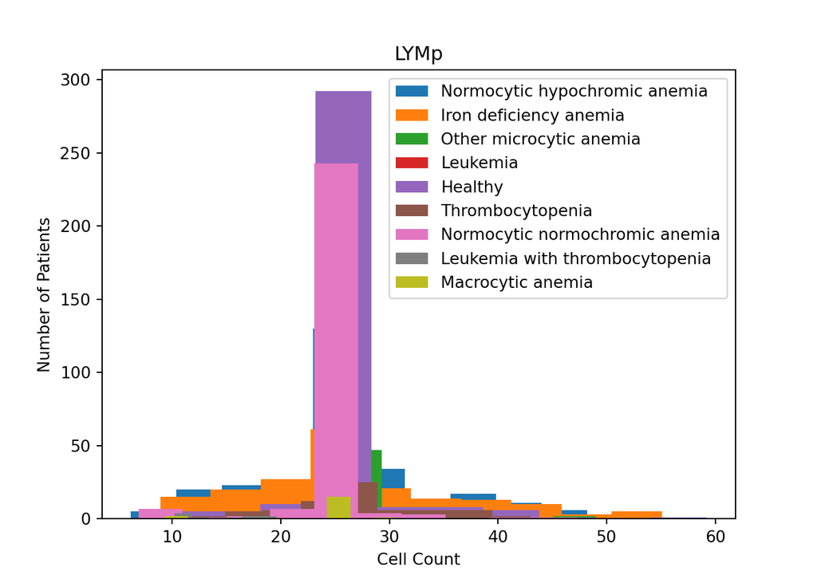

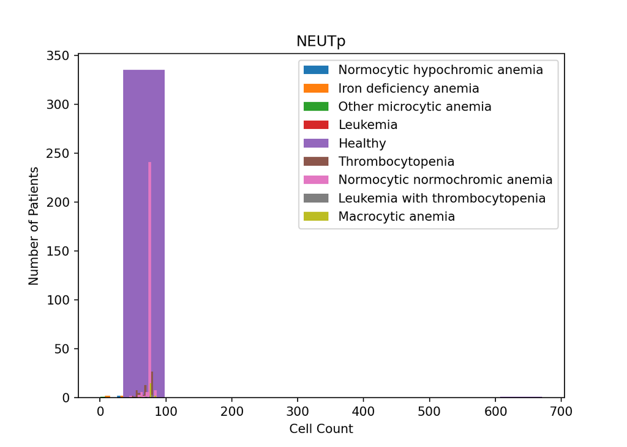

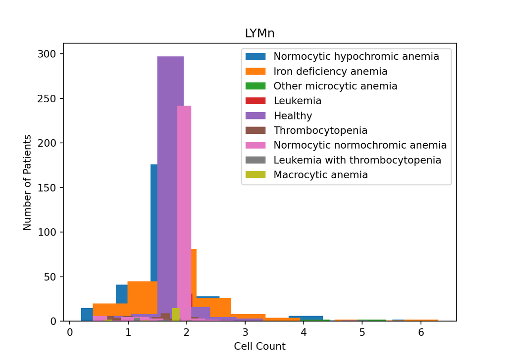

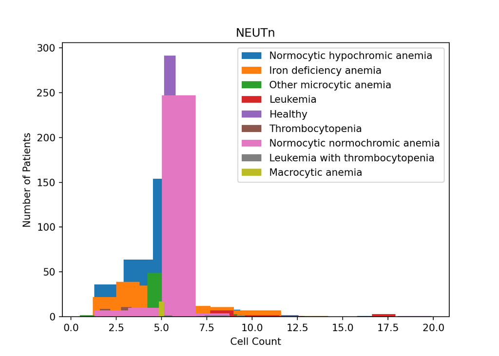

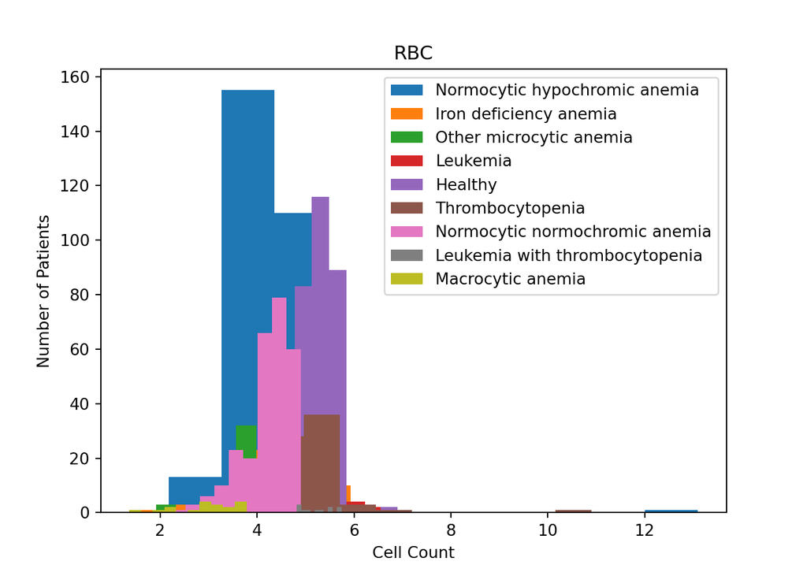

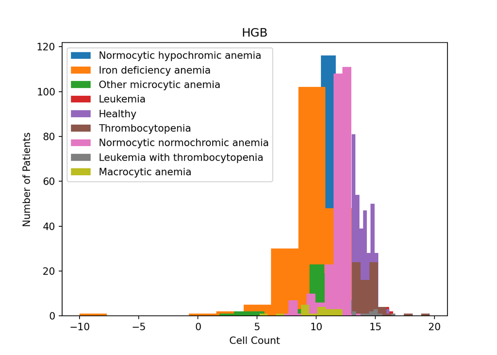

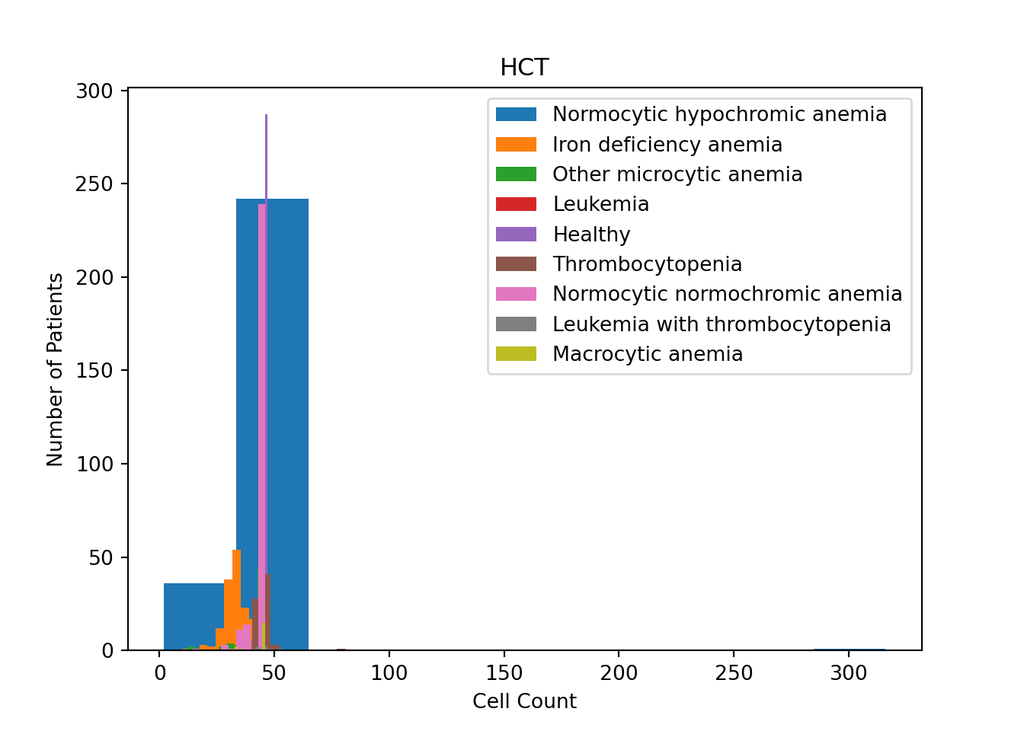

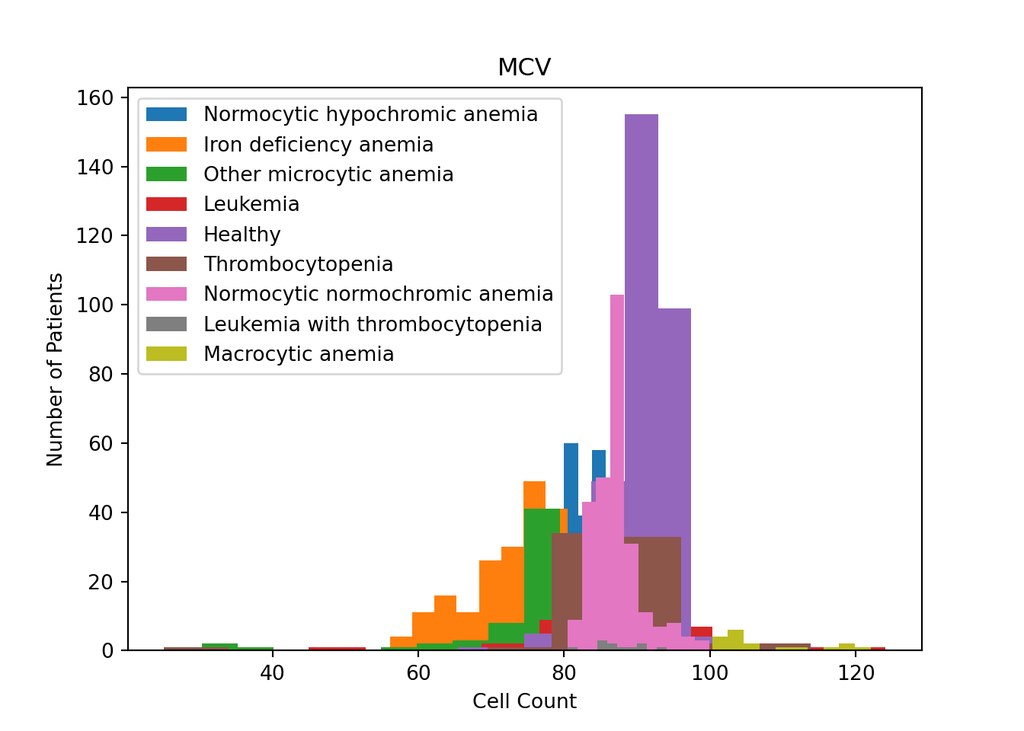

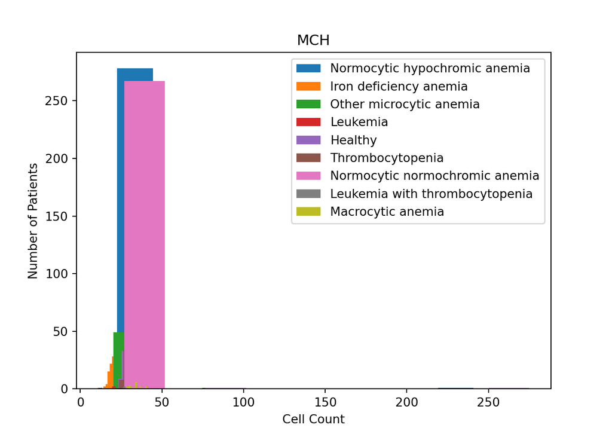

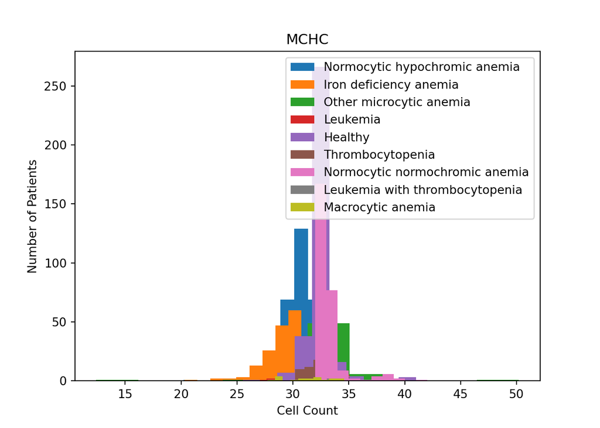

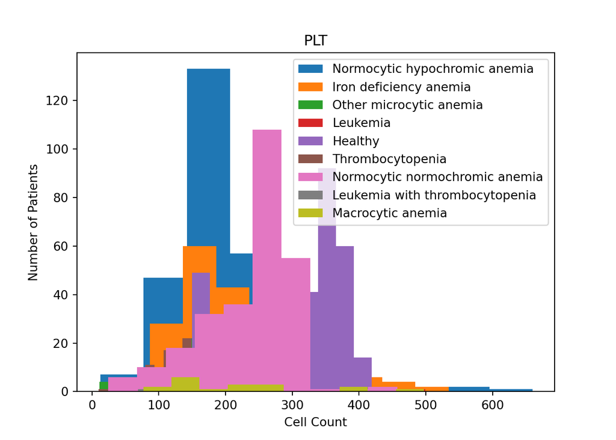

[1 more figures not shown]

## 3 Partition Training and Testing Data

ScikitLearn is a powerful and very popular machine learning library within Python. I will use this single library to build all three of my models. It requires the target variable to be separated from all predictive features, so that is where I will begin in making my training and testing data sets.

```python
X = df.iloc[:,0:-1]   # predictor columns
y = df.iloc[:,-1]   # target column
```

Since I am building a heterogeneous ensemble, it will be convenient to train all three models on the same data set, with a small caveat for ANN that will be seen later. I will partition my data then scale to prevent data leakage caused by scaling with the testing data included. this scaling is necessary for SVC because it is a distance-based model and ANN because of its back-calculation process to apply universal weights to each node in the model, shared by all features. Random forest is robust enough to handle the scaling of data required for ANN and SVM.

```python
# partition training and testing data
X_train, X_test, y_train, y_test = train_test_split(X, y, test_size=0.2, random_state=123, stratify=y)
# create a scale object for svm and neural network
SS = StandardScaler()
SS.fit(X_train);
X_train = SS.transform(X_train)    # scale training data
X_test = SS.transform(X_test)    # scale testing data
kf = StratifiedKFold(n_splits=5, shuffle=True, random_state=42)   # for cross-validation
```

## 4 Model Building

### 4.1 Support Vector Classifier

Support vector machine, or more specifically, support vector classifier, is a supervised machine learning algorithm designed to find a plane in space that most effectively divides classes of the target feature. These planes are optimized according to kernel functions, making mapping into higher dimensional planes possible. This is one hyperparameter we will optimize. The margin of the plane can also be optimized in a trade-off between achieving greater division at the cost of misclassifying certain data points. This is controlled by C, another hyperparameter we will tune, where a smaller C produces a wider margin but tolerates misclassification while a larger C leads to stricter classification but risks overfitting. The last hyperparameter, gamma, controls how highly a single training example may influence the model where the value of gamma is inversely proportional to its influence.

```python
svc_model = SVC()
svc_model.fit(X_train, y_train);
y_pred = svc_model.predict(X_test)
base_f1 = round(f1_score(y_test, y_pred, average='weighted'), 3)
print("SVC model F1 before tuning: ", base_f1)
```

```
## SVC model F1 before tuning:  0.831
```

```python
Cs = [10, 100, 200]
gammas = ['scale', 0.01, .1, 1]
kernels = ['rbf', 'linear']

best_C = 1.0
best_gamma = 'scale'
best_kernel = 'rbf'
best_f1 = base_f1

for c in Cs:
  for g in gammas:
    for k in kernels:
      model = SVC(C=c, gamma=g, kernel=k)
      f1s = cross_val_score(model, X_train, y_train, cv=kf, scoring="f1_weighted")
      mean_f1 = round(np.mean(f1s), 3)
      if mean_f1 >= best_f1:
        best_f1 = mean_f1
        best_C = c
        best_gamma = g
        best_kernel = k
```

[output not shown]

```
## SVC Model Classification Report:
##                                  precision    recall  f1-score   support
##
##                        Healthy       0.91      0.93      0.92        67
##         Iron deficiency anemia       0.90      0.97      0.94        38
##                       Leukemia       1.00      0.78      0.88         9
## Leukemia with thrombocytopenia       1.00      0.50      0.67         2
##              Macrocytic anemia       1.00      1.00      1.00         4
##  Normocytic hypochromic anemia       0.89      0.91      0.90        56
## Normocytic normochromic anemia       0.94      0.91      0.92        54
##        Other microcytic anemia       0.91      0.83      0.87        12
##               Thrombocytopenia       0.94      1.00      0.97        15
##
##                       accuracy                           0.92       257
##                      macro avg       0.94      0.87      0.90       257
##                   weighted avg       0.92      0.92      0.92       257
```

### 4.2 Random Forest

Random Forest is an ensemble learning algorithm that constructs multiple decision trees during training and outputs the mode of their individual predictions for classification tasks. The algorithm’s performance is influenced by several key hyperparameters that control both the complexity of individual trees and the diversity of the forest. The hyperparameters tuned in this loop include number of estimators, specifying the number of decision trees in the forest, minimum sample splits, determining the minimum number of samples required to split an internal node, and minimum sample leaves, sets the minimum number of samples that must be present in a leaf node. Other hyperparameters that reliably optimized to their default values were left out of the tuning process shown here in an effort to reduce the run time of the program.

```python
rf_model = RandomForestClassifier()
rf_model.fit(X_train, y_train);
y_pred = rf_model.predict(X_test)
base_f1 = round(f1_score(y_test, y_pred, average='weighted'), 3)
print("RF model F1 before tuning: ", base_f1)
```

```
## RF model F1 before tuning:  0.972
```

```python
estimators = [75, 100, 150]
splits = [2, 3, 4]
leaves = [1, 2, 3]

# set starting parameters to the defaults
best_est = 100
best_split = 2
best_leaf = 1
best_f1 = base_f1

for e in estimators:
  for s in splits:
    for l in leaves:
      model = RandomForestClassifier(n_estimators=e,
                          min_samples_split=s,
                          min_samples_leaf=l)
      f1s = cross_val_score(model, X_train, y_train, cv=kf, scoring='f1_weighted')
      mean_f1 = round(np.mean(f1s), 3)
      if mean_f1 >= best_f1:
        best_f1 = mean_f1
        best_est = e
        best_split = s
        best_leaf = l
```

```
## RF model after tuning:
## Best score:  0.984
## Best F1 w/ holdout:  0.977
## Best # estimators:  150
## Best # splits:  3
## Best leaf:  1
```

```
## RF Model Classification Report:
##                                  precision    recall  f1-score   support
##
##                        Healthy       0.99      0.99      0.99        67
##         Iron deficiency anemia       0.97      1.00      0.99        38
##                       Leukemia       1.00      0.89      0.94         9
## Leukemia with thrombocytopenia       0.67      1.00      0.80         2
##              Macrocytic anemia       1.00      0.75      0.86         4
##  Normocytic hypochromic anemia       0.98      1.00      0.99        56
## Normocytic normochromic anemia       1.00      0.98      0.99        54
##        Other microcytic anemia       1.00      1.00      1.00        12
##               Thrombocytopenia       1.00      1.00      1.00        15
##
##                       accuracy                           0.98       257
##                      macro avg       0.96      0.96      0.95       257
##                   weighted avg       0.99      0.98      0.98       257
```

### 4.3 Artificial Neural Network

Artificial neural network is a powerful model inspired by the structure of biological neurons, consisting of interconnected layers of nodes that process information through weighted connections. The network learns patterns in data by adjusting these connection weights through forward and backward training. The hyperparameters tuned are hidden layers, initial learning rate, and learning rate decrease, which all describe ways in which the network constructs and trains itself. The maximum number of iterations was adjusted to avoid convergence warnings. Oftentimes, early stopping can be used to prevent overfitting of a model. However, this model took many iterations beyond the default number to train to completion so early stopping was not a concern. I mentioned before that there is one caveat to the ability to build all three models from the same training data set. Neural Networks cannot process non-numeric data. Even the target variable must be numeric. Before generating a model, we must encode the categorical target variable. I initially attempted this with one-hot encoding carried out through the *sklearn.preprocessing* function but my program begin crashing once stratified sampling was involved so I was forced to switch to another encoding method. Claude helped me identify which encoding package would be compatible with *StratifiedKFold* as well as how to inverse transform the predictions back to text values for the sake of interpreting results and later integration into the heterogeneous ensemble function.

```python
le = LabelEncoder()
y_train_enc = le.fit_transform(y_train)
y_test_enc = le.transform(y_test)
```

```
## ANN model F1 before tuning:  0.891
```

```python
layers = [75, 100, 150]
init = [0.0001, 0.001, 0.01]
rate = ['constant', 'adaptive']

best_layer = 100
best_init = 0.001
best_rate = 'constant'
best_f1 = base_f1

for l in layers:
  for r in init:
    for s in rate:
      model = MLPClassifier(hidden_layer_sizes=(l,),
                            learning_rate_init=r,
                            learning_rate=s,
                            max_iter=3000)
      f1s = cross_val_score(model, X_train, y_train_enc, cv=kf, scoring='f1_weighted')
      mean_f1 = np.mean(f1s)
      if mean_f1 >= best_f1:
        best_f1 = mean_f1
        best_layer = l
        best_init = r
        best_rate = s
```

```
## ANN model after tuning:
## Best score:  0.899
## Best F1 w/ holdout:  0.8965880925415689
## Best # hidden layers:  100
## Best initial learning rate:  0.001
## Best rate type:  constant
```

```
## ANN Model Classification report:
##                                  precision    recall  f1-score   support
##
##                        Healthy       0.94      0.96      0.95        67
##         Iron deficiency anemia       0.89      0.89      0.89        38
##                       Leukemia       1.00      0.78      0.88         9
## Leukemia with thrombocytopenia       0.00      0.00      0.00         2
##              Macrocytic anemia       0.75      0.75      0.75         4
##  Normocytic hypochromic anemia       0.85      0.91      0.88        56
## Normocytic normochromic anemia       0.94      0.89      0.91        54
##        Other microcytic anemia       0.91      0.83      0.87        12
##               Thrombocytopenia       0.82      0.93      0.88        15
##
##                       accuracy                           0.90       257
##                      macro avg       0.79      0.77      0.78       257
##                   weighted avg       0.90      0.90      0.90       257
```

### 4.4 Heterogeneous Ensemble

All of my models have great accuracy but my random forest model in particular is almost always accurate. This being the case, my ensemble model will always choose the prediction of the model with the highest F1 score except in the event that both of the other models agree with each other, then it will choose their prediction. This is a method of stacking by way of weighting predictions by their respective model’s F1 scores, where if the rare event occurs that the primary model disagrees with the secondary and tertiary models, but the later two agree with each other, they will override the prediction of the primary model. Otherwise, the ensemble effectively always chooses the primary model’s prediction. My function will take 7 arguments, the 3 models (which will have default arguments), the average F1 scores of each model saved during the process of cross-validation, and data on which to make predictions.

```python
def ensemble(new_data, model1=svc_model, model2=rf_model, model3=ann_model,
f1_1=svc_mean_f1, f1_2=rf_mean_f1, f1_3=ann_mean_f1):

  # SVC information
  svc_dict = {'model': model1, 'predictions': model1.predict(new_data), 'f1': f1_1}

  # RF information
  rf_dict = {'model': model2, 'predictions': model2.predict(new_data), 'f1': f1_2}

  # ANN information (categorizing predictions)
  ann_dict = {'model': model3, 'predictions': le.inverse_transform(model3.predict(new_data)), 'f1': f1_3}

  dict_list = [svc_dict, rf_dict, ann_dict]
  classifiers = {}    # dictionary of dictionaries where models will be ranked

  # find classifier with highest F1
  best_f1 = np.max([f1_1, f1_2, f1_3])

  # assign model priority by F1 value
  for d in dict_list:
    if d['f1'] == best_f1:
      classifiers['primary'] = d
    elif len(classifiers) < 2:
      classifiers['secondary'] = d
    else:
      classifiers['tertiary'] = d

  ens_pred = []

  # assemble predictions
  for i in range(len(new_data)):
    prim_pred = classifiers['primary']['predictions'][i]
    sec_pred = classifiers['secondary']['predictions'][i]
    tert_pred = classifiers['tertiary']['predictions'][i]

    if sec_pred == tert_pred:
      ens_pred.append(sec_pred)
    else:
      ens_pred.append(prim_pred)

  return ens_pred
```

```
## Ensemble Model Classification report:
##                                  precision    recall  f1-score   support
##
##                        Healthy       0.96      0.97      0.96        67
##         Iron deficiency anemia       0.90      1.00      0.95        38
##                       Leukemia       1.00      0.89      0.94         9
## Leukemia with thrombocytopenia       0.50      0.50      0.50         2
##              Macrocytic anemia       1.00      1.00      1.00         4
##  Normocytic hypochromic anemia       0.91      0.93      0.92        56
## Normocytic normochromic anemia       0.98      0.91      0.94        54
##        Other microcytic anemia       1.00      0.83      0.91        12
##               Thrombocytopenia       0.94      1.00      0.97        15
##
##                       accuracy                           0.94       257
##                      macro avg       0.91      0.89      0.90       257
##                   weighted avg       0.94      0.94      0.94       257
```

## 5 Summary

[output not shown]

## 6 References

- Artificium - Dr. Martin Schedulbauer
- [Data Source](https://www.kaggle.com/datasets/ehababoelnaga/anemia-types-classification)
- SciKit Learn Documentation
- [Scipy Documentation](https://docs.scipy.org/doc/scipy/reference/generated/scipy.stats.shapiro.html)
- [Hyperparameters](https://stackabuse.com/understanding-svm-hyperparameters/)
- Youtube: Ryan and Matt Data Science, freeCodeCamp.org and Kylie Young
- AI Assistance: Claude AI & Open AI ChatGPT